# Eksploracja danych geoprzestrzennych

## GMM

## Mapy porównawcze dla kmeans i gmm.

### PCA vs Wybrane/ 3 vs 4 skupiska / kmeans vs gmm.

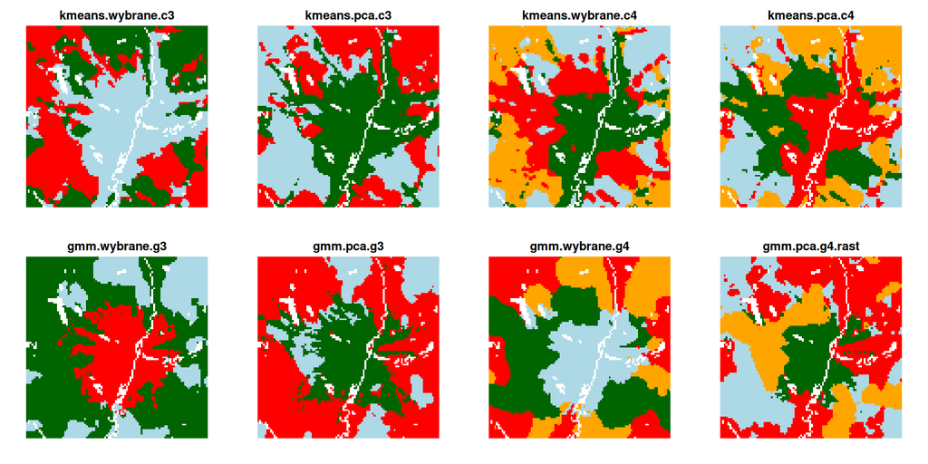

Kmeans działa dobrze zarówno dla 3, jak i 4 klastrów, wybranych zmiennych i składowych PCA. GMM tworzy mniej sensowne klastry. Mam wrażenie, że GMM działa lepiej z oryginalnymi zmiennymi niż ze składowymi, a kmeans odwrotnie.

## Weryfikacja jakości klasyfikacji (Silhouette).

### Obliczenia.

### Wykresy.

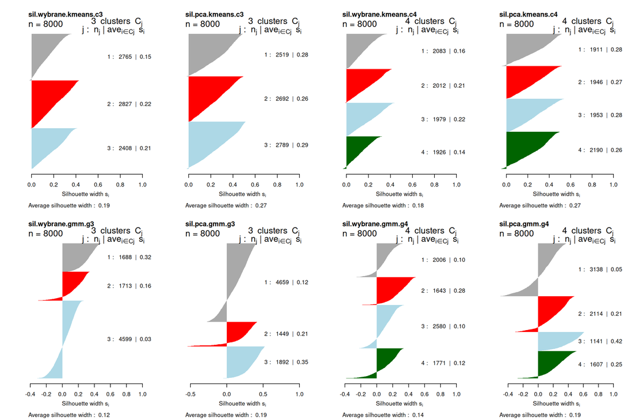

Kmenas na podstawie składowych PCA tworzy najlepsze klastry, spójne wewnętrznie i odróżniające się od innych klastrów. Do opisu wybieram modele kmeans dla składowych PCA i liczby klastrów trzech i czterech.

## Interpretacja

Do efektywniejszej wizualizacji biorę próbę 8 tysięcy punktów (oryginalnych, bez usuwania wartości odstających) i skaluję zmienne do zakresu (0,1). Analizuję zmienne niezależne, na podstawie których wyznaczono klastry, oraz ceny z punktów trafiających do danego klastra.

### Wzięcie próby.

### Funkcje pomocnicze.

### Mapy klastrów.

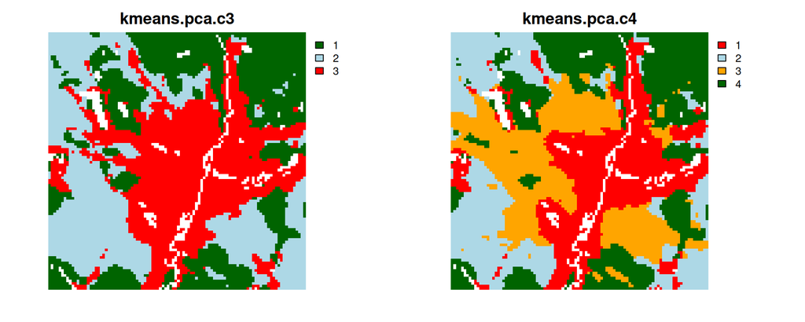

### Opis trzech klastrów.

Srednie wartosci cech w klastrach zokraglone do 10 (cena - [PLN/m2], pozostale - [m])

| klaster | cena | distbuses | distcentre | distgreens | distroads | diststations | distwaters |
| --- | --- | --- | --- | --- | --- | --- | --- |
| 1 | 7900 | 1120 | 11610 | 180 | 2340 | 3790 | 1720 |
| 2 | 6430 | 630 | 11080 | 1230 | 1090 | 3500 | 2680 |
| 3 | 8390 | 280 | 6640 | 440 | 620 | 2950 | 1210 |

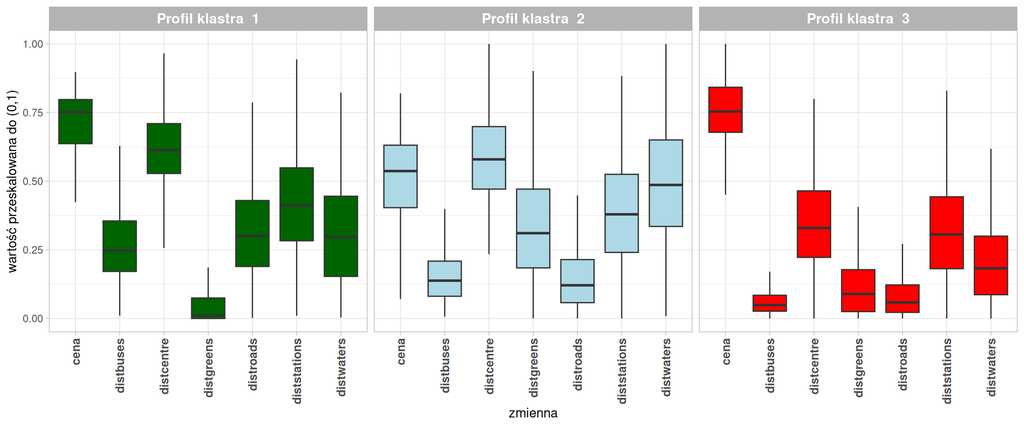

**Klaster 3 (czerwony):** rejony centralne

- **cena**: wysoka
- **wysokie**:
- **niskie**: odległość od centrum, wody, terenów zielonych, przystanków autobusowych

To obszary korzystnie zlokalizowane, gdzie nieruchomości osiągają wysokie ceny. Większość znajduje się w środku mapy, reszta w dobrze skomunikowanych miejscach, niedaleko wody i zieleni.

- **cena**: niska
- **wysokie**: odległość od centrum, wody, terenów zielonych
- **niskie**:

Przeciwieństwo rejonów centralnych - obszary daleko od centrum, wody, zieleni, gdzie nieruchomości są tanie. Mogą tu być pola i wsie.

- **cena**: średnio-wysoka
- **wysokie**: odległość od centrum
- **niskie**: odległość od terenów zielonych

To obszary oddalone od centrum, na których przeważa roślinność. Nieliczne nieruchomości mogą osiągać dość wysokie ceny.

### Opis czterech klastrów.

Srednie wartosci cech w klastrach zokraglone do 10 (cena - [PLN/m2], pozostale - [m])

| klaster | cena | distbuses | distcentre | distgreens | distroads | diststations | distwaters |
| --- | --- | --- | --- | --- | --- | --- | --- |
| 1 | 8670 | 300 | 6840 | 330 | 580 | 2260 | 820 |
| 2 | 6410 | 750 | 12370 | 1190 | 1090 | 2550 | 2410 |
| 3 | 7380 | 360 | 7610 | 850 | 910 | 4730 | 2460 |
| 4 | 8010 | 1170 | 11680 | 170 | 2520 | 3960 | 1770 |

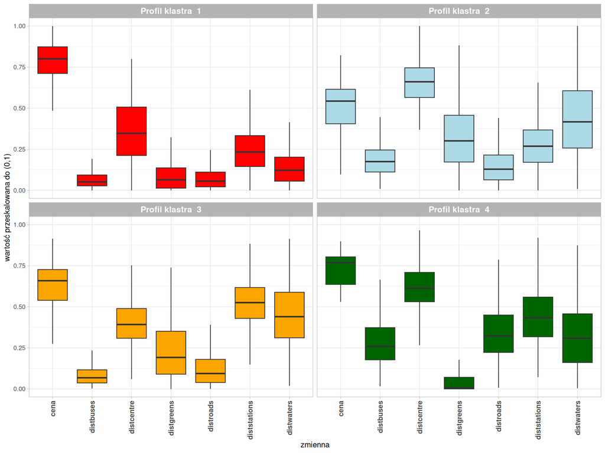

**Klaster 1 (czerwony):** rejony centralne

- **cena**: wysoka
- **wysokie**:
- **niskie**: odległość od centrum, wody, terenów zielonych, przystanków autobusowych

To obszary korzystnie zlokalizowane, gdzie nieruchomości osiągają wysokie ceny. Większość znajduje się w środku mapy, reszta w dobrze skomunikowanych miejscach, niedaleko wody i zieleni. Zalicza się tu m.in. centrum Poznania i Swarzędz.

**Klaster 2 (jasnoniebieski):** peryferia

- **cena**: niska
- **wysokie**: odległość od centrum, wody, terenów zielonych
- **średnie**: odległość od przystanków autobusowych
- **niskie**:

Przeciwieństwo rejonów centralnych - obszary daleko od centrum, wody, zieleni, gdzie nieruchomości są tanie. Zaliczają się tu np. wsie na południe od Swarzędza, jak Kruszewnia.

**Klaster 3 (pomarańczowy):** skomunikowane peryferia

- **cena**: średnio-niska
- **wysokie**: odległość od wody
- **średnie**: odległość od centrum, terenów zielonych
- **niskie**: odległość od przystanków autobusowych

**Klaster 4 (zielony):** zielone osady

- **cena**: średnio-wysoka
- **wysokie**: odległość od centrum, przystanków autobusowych, głównych dróg
- **średnie**: odległość od wody
- **niskie**: odległość od terenów zielonych

To obszary oddalone od centrum, na których przeważa roślinność. Nieliczne nieruchomości mogą osiągać dość wysokie ceny. Zaliczają się tu np. lasy w dolinie Michałówki, między Swarzędzem a dzielnicą Szczepankowo-Spławie-Krzesinki.

# Kriging.

## Funkcja pomocnicza.

## Kriging prosty i zwykły.

### Jittering.

Dla krigingu trzeba minimalnie przesunąć punkty, żeby żadne dwa nie miały dokładnie takich samych współrzędnych.

### Podział na zbiór treningowy i testowy.

Tak jak w przypadku wcześniejszych modeli dzielę zbiór w stosunku 70 - 30, jednak przydzielone punkty mogą się różnić.

### Semiwariogram.

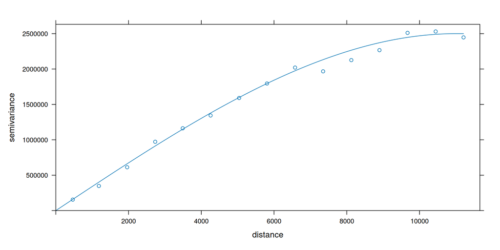

### Siatka krigingowa.

### Prosty kriging (SK).

#### Obliczenia.

#### Wyniki na zbiorze treningowym.

```
Object of class SpatialPointsDataFrame
Coordinates:
               min      max
coords.x1 345247.3 369850.8
coords.x2 495082.1 519707.6
Is projected: TRUE
proj4string :
[+proj=tmerc +lat_0=0 +lon_0=19 +k=0.9993 +x_0=500000 +y_0=-5300000
+ellps=GRS80 +towgs84=0,0,0,0,0,0,0 +units=m +no_defs]
Number of points: 364
Data attributes:
   var1.pred       var1.var            observed        residual
 Min.   :3242   Min.   :    545.8   Min.   : 2526   Min.   :-2235.29
 1st Qu.:6920   1st Qu.:  90573.3   1st Qu.: 6956   1st Qu.: -308.96
 Median :8011   Median : 153607.9   Median : 8006   Median :   37.74
 Mean   :7710   Mean   : 198843.0   Mean   : 7727   Mean   :   16.41
 3rd Qu.:8739   3rd Qu.: 240881.8   3rd Qu.: 8792   3rd Qu.:  342.62
 Max.   :9873   Max.   :1448162.3   Max.   :10064   Max.   : 2412.45
     zscore               fold
 Min.   :-22.47013   Min.   :  1.00
 1st Qu.: -0.85360   1st Qu.: 91.75
 Median :  0.11138   Median :182.50
 Mean   :  0.01417   Mean   :182.50
 3rd Qu.:  0.89352   3rd Qu.:273.25
 Max.   : 22.74898   Max.   :364.00
```

#### Test.

```
[1] "RMSE na zbiorze testowym w PLN wynosi: 421.639238768905"
```

### Zwykły kriging (OK).

#### Obliczenia.

#### Wyniki na zbiorze treningowym.

```
Object of class SpatialPointsDataFrame
Coordinates:
               min      max
coords.x1 345247.3 369850.8
coords.x2 495082.1 519707.6
Is projected: TRUE
proj4string :
[+proj=tmerc +lat_0=0 +lon_0=19 +k=0.9993 +x_0=500000 +y_0=-5300000
+ellps=GRS80 +towgs84=0,0,0,0,0,0,0 +units=m +no_defs]
Number of points: 364
Data attributes:
   var1.pred       var1.var            observed        residual
 Min.   :3193   Min.   :    545.8   Min.   : 2526   Min.   :-2203.09
 1st Qu.:6935   1st Qu.:  90637.9   1st Qu.: 6956   1st Qu.: -313.29
 Median :8016   Median : 153937.5   Median : 8006   Median :   44.56
 Mean   :7701   Mean   : 202083.8   Mean   : 7727   Mean   :   25.34
 3rd Qu.:8706   3rd Qu.: 243200.9   3rd Qu.: 8792   3rd Qu.:  356.77
 Max.   :9934   Max.   :1610887.1   Max.   :10064   Max.   : 2834.78
     zscore               fold
 Min.   :-22.46867   Min.   :  1.00
 1st Qu.: -0.86161   1st Qu.: 91.75
 Median :  0.10310   Median :182.50
 Mean   :  0.02474   Mean   :182.50
 3rd Qu.:  0.87090   3rd Qu.:273.25
 Max.   : 22.74524   Max.   :364.00
```

#### Test.

```
[1] "RMSE na zbiorze testowym w PLN wynosi: 407.03077851893"
```

## Kokriging.

Kriging ceny z punktów z pomocniczą zmienną PC1 - o wartościach obliczonych we wszystkich komórkach rastra.

### Jittering.

### Skalowanie zmiennych.

Żeby użyć pomocniczej zmiennej o innej skali niż cena, obie zmienne skaluję do zakresu (0,1).

### Podział na zbiór treningowy i testowy.

### Semiwariogramy i semiwariogram krzyżowy.

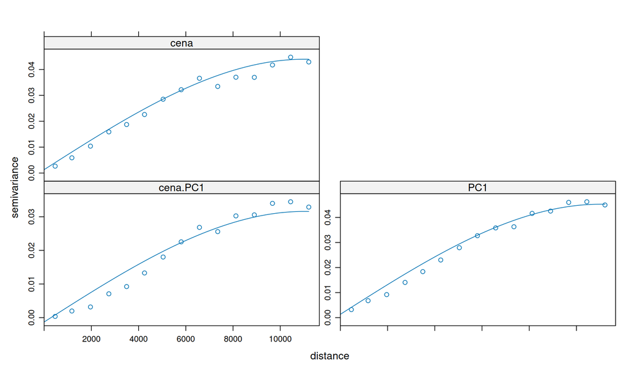

### Siatka krigingowa.

W siatce poza punktami ze zbioru treningowego są wszystkie wartości PC1.

### Obliczenia.

### Wyniki na zbiorze treningowym.

```
Object of class SpatialPointsDataFrame
Coordinates:
               min      max
coords.x1 345246.5 369849.5
coords.x2 495083.4 519707.9
Is projected: TRUE
proj4string :
[+proj=tmerc +lat_0=0 +lon_0=19 +k=0.9993 +x_0=500000 +y_0=-5300000
+ellps=GRS80 +towgs84=0,0,0,0,0,0,0 +units=m +no_defs]
Number of points: 364
Data attributes:
   cena.pred         cena.var             observed         residual
 Min.   :0.1307   Min.   :0.00009863   Min.   :0.0000   Min.   :-0.320281
 1st Qu.:0.5562   1st Qu.:0.00305066   1st Qu.:0.5664   1st Qu.:-0.043411
 Median :0.6948   Median :0.00414018   Median :0.7007   Median : 0.003774
 Mean   :0.6624   Mean   :0.00437862   Mean   :0.6649   Mean   : 0.002517
 3rd Qu.:0.7941   3rd Qu.:0.00528070   3rd Qu.:0.8011   3rd Qu.: 0.044832
 Max.   :0.9578   Max.   :0.01515138   Max.   :0.9637   Max.   : 0.550818
     zscore               fold
 Min.   :-10.86144   Min.   :  1.00
 1st Qu.: -0.70405   1st Qu.: 91.75
 Median :  0.06340   Median :182.50
 Mean   :  0.01555   Mean   :182.50
 3rd Qu.:  0.67492   3rd Qu.:273.25
 Max.   : 10.94655   Max.   :364.00
```

Do oceny należy odwrócić skalowanie ceny.

### Test.

```
[1] "RMSE na zbiorze testowym w PLN wynosi: 449.336161781276"
```

## Mapy predykcji.

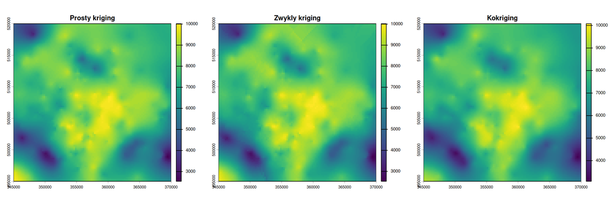

## Wyniki.

| kriging | zmienne | test.rmse |
| --- | --- | --- |
| prosty (SK) | cena | 421.64 |
| zwykly (OK) | cena | 407.03 |
| kokriging | cena, PC1 | 449.34 |

Zwykły kriging okazał się najlepszą testowaną metodą przewidywania cen ze względu na RMSE (407 PLN/m2). Prosty kriging osiąga gorsze wyniki, ponieważ średnia cena nieruchomości nie jest stała geograficznie. Dodanie PC1 w kokrigingu zamiast polepszać, pogarsza wyniki. Może tak być dlatego, że wszystkie zmienne, na których podstawie wyliczono PC1, to zmienne związane przestrzenią, odległością. Kriging sam w sobie uwzględnia położenie geograficzne, więc takie zmienne, które korelują z ceną ze względu na lokalizację, a nie inne obiektywne powiązania, mu nie pomagają. Wszystkie metody krigingu osiągają niższe RMSE, niż najlepsza z metod nieprzestrzennych (LWR, 581 PLN/m2).